# classification k-mer

# Initialisation

We will start by load all library needed, and our list (they can be change in fonction of the organisme).

```r
library(ggplot2)
library(gridExtra)
```

```r
Coding=c('IG_C_gene', 'IG_D_gene', 'IG_J_gene', 'IG_LV_gene', 'IG_M_gene', 'IG_V_gene', 'IG_Z_gene', 'nonsense_mediated_decay', 'nontranslating_CDS', 'non_stop_decay', 'protein_coding', 'TR_C_gene', 'TR_D_gene', 'TR_gene', 'TR_J_gene', 'TR_V_gene')
Pseudogene=c('transcribed_unitary_pseudogene','disrupted_domain', 'IG_C_pseudogene', 'IG_J_pseudogene', 'IG_pseudogene', 'IG_V_pseudogene', 'processed_pseudogene', 'pseudogene', 'transcribed_processed_pseudogene', 'transcribed_unprocessed_pseudogene', 'translated_processed_pseudogene', 'translated_unprocessed_pseudogene', 'TR_J_pseudogene', 'TR_V_pseudogene', 'unitary_pseudogene', 'unprocessed_pseudogene','polymorphic_pseudogene')
LongNC=c('macro_lncRNA','bidirectional_promoter_lncRNA','sense_intronic','3prime_overlapping_ncRNA','ambiguous_orf','antisense','lincRNA','ncrna_host','non_coding','processed_transcript','retained_intron','sense_overlapping')
ShortNC=c('3prime_overlapping_ncRNA','scaRNA','miRNA', 'miRNA_pseudogene', 'misc_RNA', 'misc_RNA_pseudogene', 'Mt_rRNA' ,'Mt_tRNA', 'Mt_tRNA_pseudogene', 'ncRNA', 'pre_miRNA', 'RNase_MRP_RNA', 'RNase_P_RNA', 'rRNA', 'rRNA_pseudogene', 'scRNA_pseudogene', 'snlRNA', 'snoRNA', 'snoRNA_pseudogene', 'snRNA', 'snRNA_pseudogene', 'SRP_RNA', 'tmRNA', 'tRNA', 'tRNA_pseudogene')
Predictif=c('TEC')
NonCoding=c('macro_lncRNA','bidirectional_promoter_lncRNA','sense_intronic','3prime_overlapping_ncRNA','ambiguous_orf','antisense','lincRNA','ncrna_host','non_coding','processed_transcript','retained_intron','sense_overlapping','3prime_overlapping_ncRNA','scaRNA','miRNA', 'miRNA_pseudogene', 'misc_RNA', 'misc_RNA_pseudogene', 'Mt_rRNA' ,'Mt_tRNA', 'Mt_tRNA_pseudogene', 'ncRNA', 'pre_miRNA', 'RNase_MRP_RNA', 'RNase_P_RNA', 'rRNA', 'rRNA_pseudogene', 'scRNA_pseudogene', 'snlRNA', 'snoRNA', 'snoRNA_pseudogene', 'snRNA', 'snRNA_pseudogene', 'SRP_RNA', 'tmRNA', 'tRNA', 'tRNA_pseudogene')
SupraFamilyName=c('Coding', 'NonCoding', 'Pseudogene', 'Predictif')
SupraFamily=list()
SupraFamily[[1]]=Coding
SupraFamily[[2]]=NonCoding
SupraFamily[[3]]=Pseudogene
SupraFamily[[4]]=Predictif
```

# Fonction

## Data import

First, we will import our Data in a list of data frame. One data frame will correspond to one family (Coding, NonCoding, Pseudogene, Predictif).

```r
DataImport = function(path, SupraFamily, NameFile) {
  Data_perFamily = list()
  for(j in seq(1,length(SupraFamily))){# for each family : Coding, NonCoding, Pseudogene, Predictif
    Data_perFamily[[j]] = data.frame() # initialisation of the family
    for(i in seq(1,length(NameFile))){# browse all subfamily
      if(is.element(NameFile[i], SupraFamily[[j]])){ # if the subfamily is in the family
        # choice of the family, it will be easier to do it know
        if(length(SupraFamily[[j]])==16){
          family = 'Coding'
        }else if(length(SupraFamily[[j]])==37){
          family = 'Non Coding'
        }else if(length(SupraFamily[[j]])==17){
          family = 'Pseudogene'
        }else{
          family = 'Predictif'
        }
        filename=paste(path,NameFile[i], ".csv",  sep="") # creation of the input filename
        tmp = read.csv(filename, header = T, sep = "\t") # read the input file in a tmp
        tmp$subfamily = NameFile[i] # adding of the subfamily
        tmp$family= family # adding of the family
        Data_perFamily[[j]] = rbind(tmp, Data_perFamily[[j]]) # new subfamily add next to the other
      }
    }
  }
  # removal of some variable
  remove(tmp)
  remove(family)
  return(Data_perFamily)
}

pathPrac='/home/anais/Documents/Data/mouse/All/Subset/'
pathCoBius = '/home/local/USHERBROOKE/vana2406/Documents/Data/mouse/All/Subset/'
pathHuman = '/home/anais/Documents/Data/human/Subset/'

NameFileMouse = c("3prime_overlapping_ncRNA","polymorphic_pseudogene","transcribed_processed_pseudogene","bidirectional_promoter_lncRNA","processed_pseudogene","transcribed_unitary_pseudogene","IG_C_gene","processed_transcript","transcribed_unprocessed_pseudogene","IG_V_gene","protein_coding","translated_processed_pseudogene","IG_V_pseudogene","pseudogene","TR_C_gene","lincRNA","retained_intron","TR_V_gene","macro_lncRNA","rRNA","TR_V_pseudogene","miRNA","sense_intronic","unitary_pseudogene","misc_RNA","sense_overlapping","unprocessed_pseudogene","nonsense_mediated_decay","snoRNA","non_stop_decay","TEC")

NameFileHuman = c("3prime_overlapping_ncRNA","antisense","bidirectional_promoter_lncRNA","IG_C_gene","IG_C_pseudogene","IG_V_gene","IG_V_geneUTR","IG_V_pseudogene","lincRNA","macro_lncRNA","miRNA","misc_RNA","non_coding","nonsense_mediated_decay","nonsense_mediated_decayUTR","non_stop_decay","non_stop_decayUTR","polymorphic_pseudogene","processed_pseudogene","processed_transcript","protein_coding","protein_codingUTR","pseudogene","retained_intron","rRNA","sense_intronic","sense_overlapping","TEC","transcribed_processed_pseudogene","transcribed_unitary_pseudogene","transcribed_unprocessed_pseudogene","TR_C_gene","TR_V_gene","TR_V_geneUTR","TR_V_pseudogene","unitary_pseudogene","unprocessed_pseudogene")

Data_Mouse_perFamily = list()
Data_Mouse_perFamily = DataImport(pathPrac, SupraFamily, NameFileMouse)

Data_Human_perFamily = list()
Data_Human_perFamily = DataImport(pathHuman, SupraFamily, NameFileHuman)
```

## Graphic

### Mean Graphic

The the graphic will be done. This is done in a function MeanGraphic(Data, family). The parameter correspond to :

- Data : the list containing all the familly data frame
- family : the family of which you want the graphic.

The graphic is done thanks to the [tuto](https://datascienceplus.com/building-barplots-with-error-bars/).

For each transcript, we compute the frequency of G4s in fonction of the position, then the mean of those frenquency is made in fonction of the localisation.

```r
MeanGraphic = function(Data, family) {
  dodge <- position_dodge(width = 0.9)
  limits <- aes(ymax = Data$Mean + Data$SE,
                ymin = Data$Mean - Data$SE)
  p <- ggplot(data = Data, aes(x = factor(Localisation), y = Mean, fill =subfamily))
  p + geom_bar(stat = "identity",
               position = position_dodge(0.9)) +
    geom_errorbar(limits, position = position_dodge(0.9),
                  width = 0.25) +
    #geom_text(aes(label=NbTRanscriptWithG4), vjust=-0.9,
    #position = position_dodge(0.9), size=3.5)+
    #scale_fill_brewer(palette="Paired")+
    labs(x = "Localisation", y = "Means") +
    ggtitle(paste("Mean of frequency for each subfamilly of", Data$family[1], "family", sep = " ")) +
    scale_fill_discrete(name = "SubFamilly")
}

#MeanGraphic(Data_Mouse_perFamily, 'Coding')
```

### Percent Graphic

Same pipeline as the MeanGraphic(). It will produce the same graphic but this time ther is no error bar, and the y’s axe corresponds to the percent of rG4s of each localisation and for each subfamily. Percent of transcript with G4 at this localisation for a subfamily.

```r
PercentGraphic = function(Data, family) {
  dodge <- position_dodge(width = 0.9)
  p <- ggplot(data = Data, aes(x = factor(Localisation), y = Percent, fill =paste(subfamily, " (",NbTRanscript,")", sep = "")))
  p + geom_bar(stat = "identity",
               position = position_dodge(0.9)) +
    geom_text(aes(label=NbTRanscriptWithG4), vjust=-0.3,
            position = position_dodge(0.9), size=3.5)+
    scale_fill_brewer(palette="Paired")+
    labs(x = "Localisation", y = "Percent") +
    ggtitle(paste("Percent of rG4s for each subfamilly of", Data$family[1], "family", sep = " ")) +
    scale_fill_discrete(name = "SubFamilly")
}

#PercentGraphic(Data_Mouse_perFamily, 'Coding')
```

### Both graphic

This function will serve to make both graphic, one under the other.

```r
Graphic = function(Data, family){
  grid.arrange(PercentGraphic(Data, family), MeanGraphic(Data, family), nrow=2)
}

#Graphic(Data_Mouse_perFamily, 'Coding')
```

### All familly

```
## which will replace the existing scale.
```

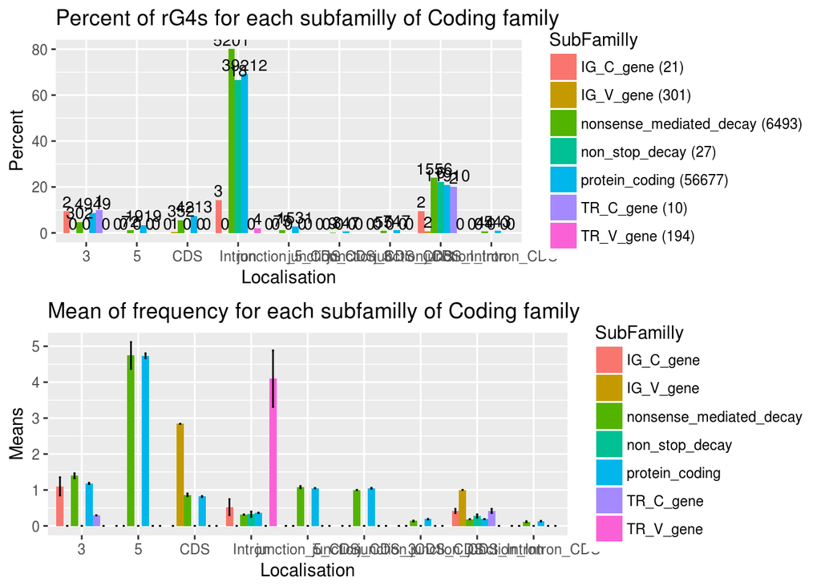

```
## which will replace the existing scale.
```

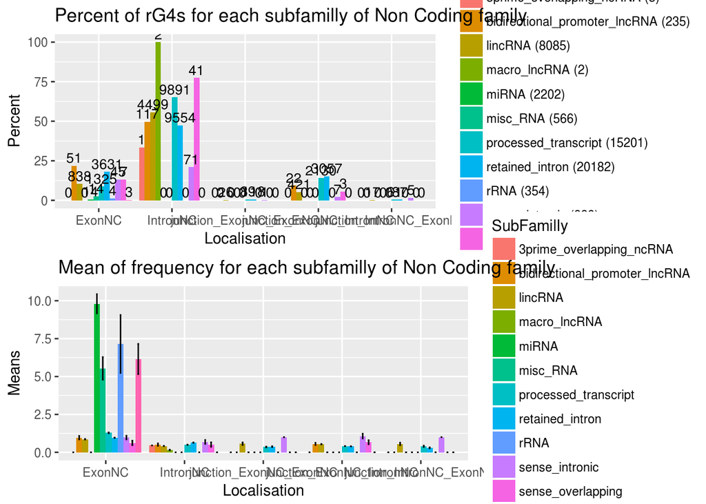

```
## which will replace the existing scale.
```

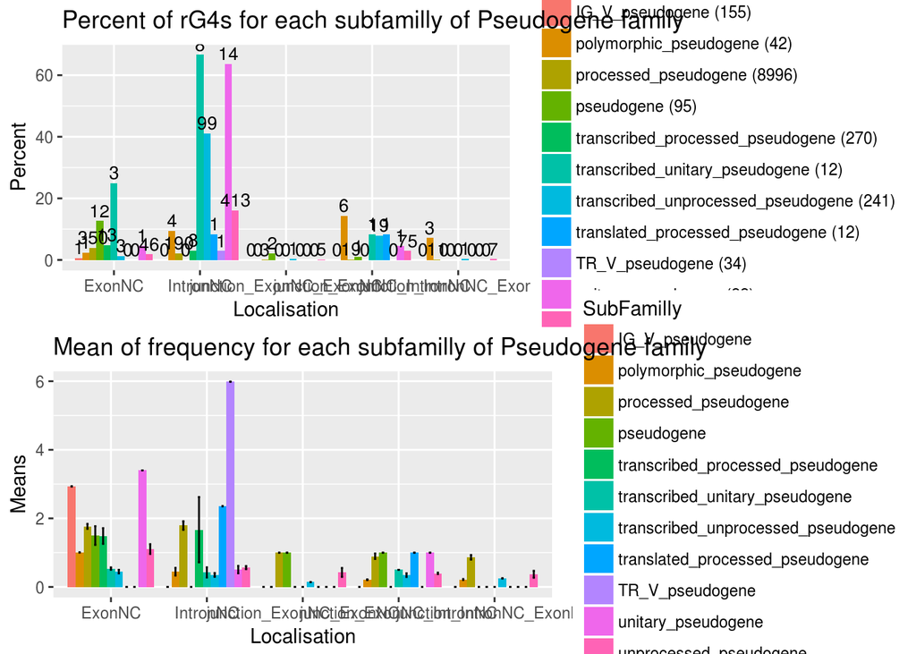

```
## which will replace the existing scale.
```

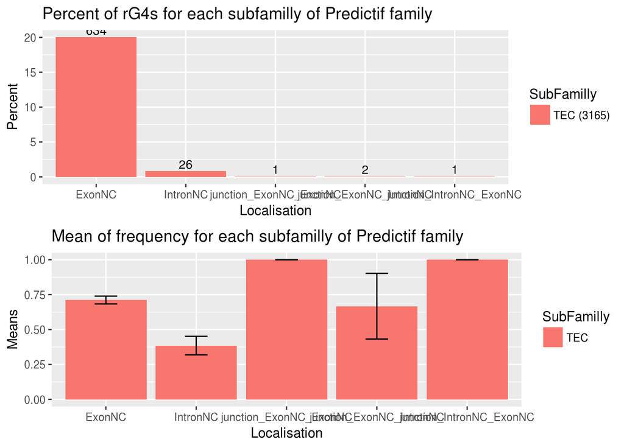

```r
AllGraphe = function(Data){
  for(i in seq(1,length(Data))){
    DataFamily = Data[[i]]
    Family = DataFamily$family[1]
    Graphic(DataFamily, Family)
  }
}

AllGraphe(Data_Mouse_perFamily)
```

```
## which will replace the existing scale.
```

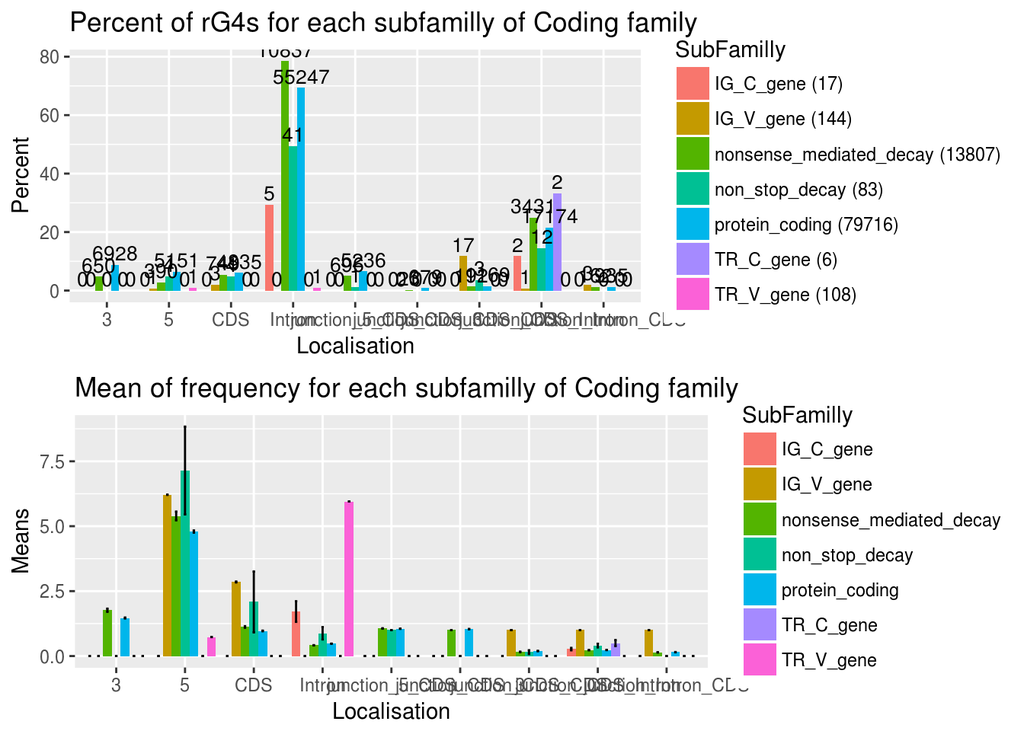

```
## which will replace the existing scale.
```

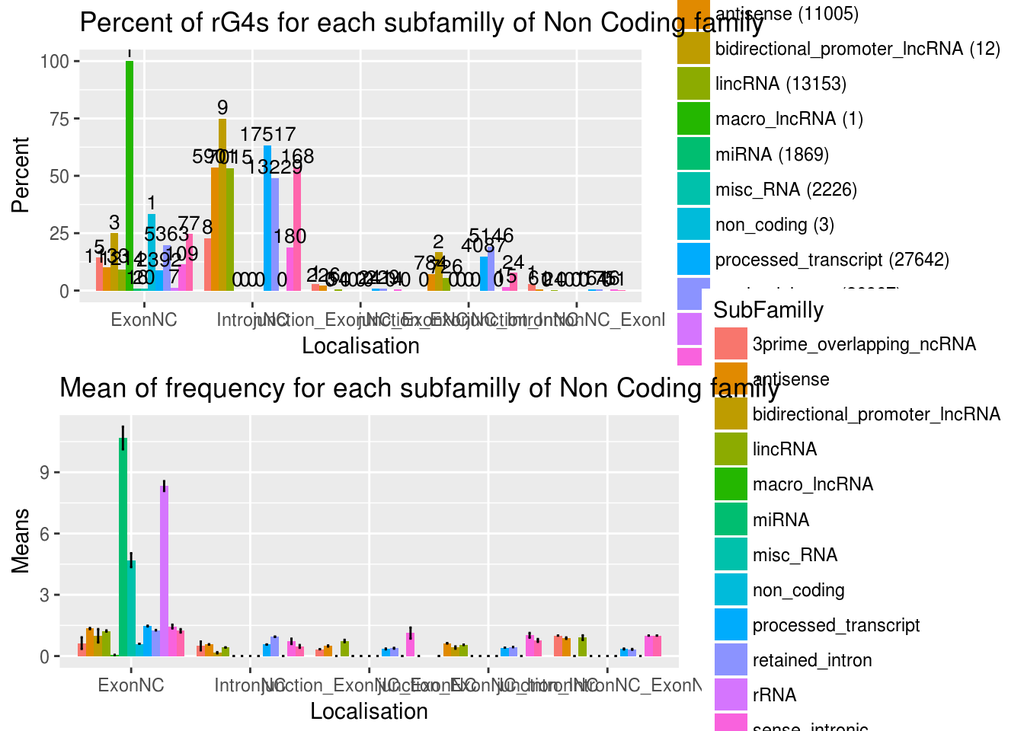

```
## which will replace the existing scale.
```

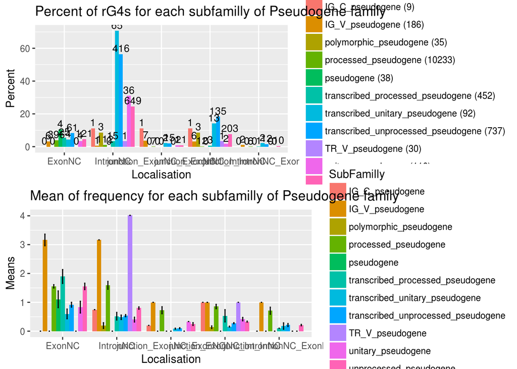

```
## which will replace the existing scale.
```

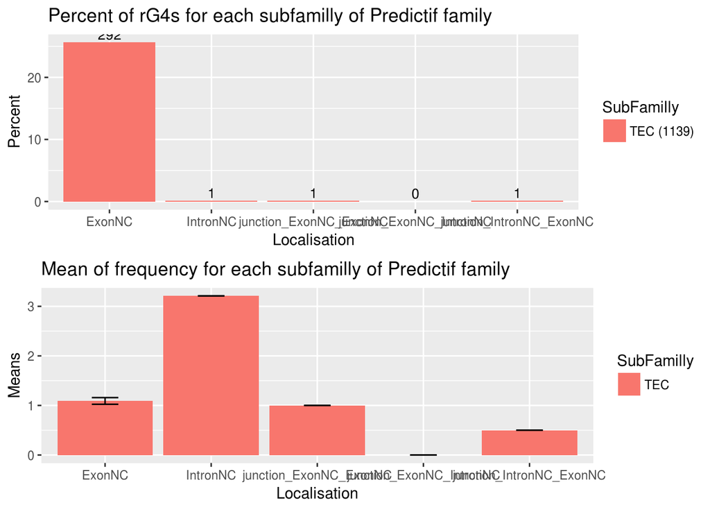

```r
AllGraphe(Data_Human_perFamily)
```